# Chain Decoder — Encoder Heads Greenland 2026

## Diagnostik: Replikate, GND, Druck

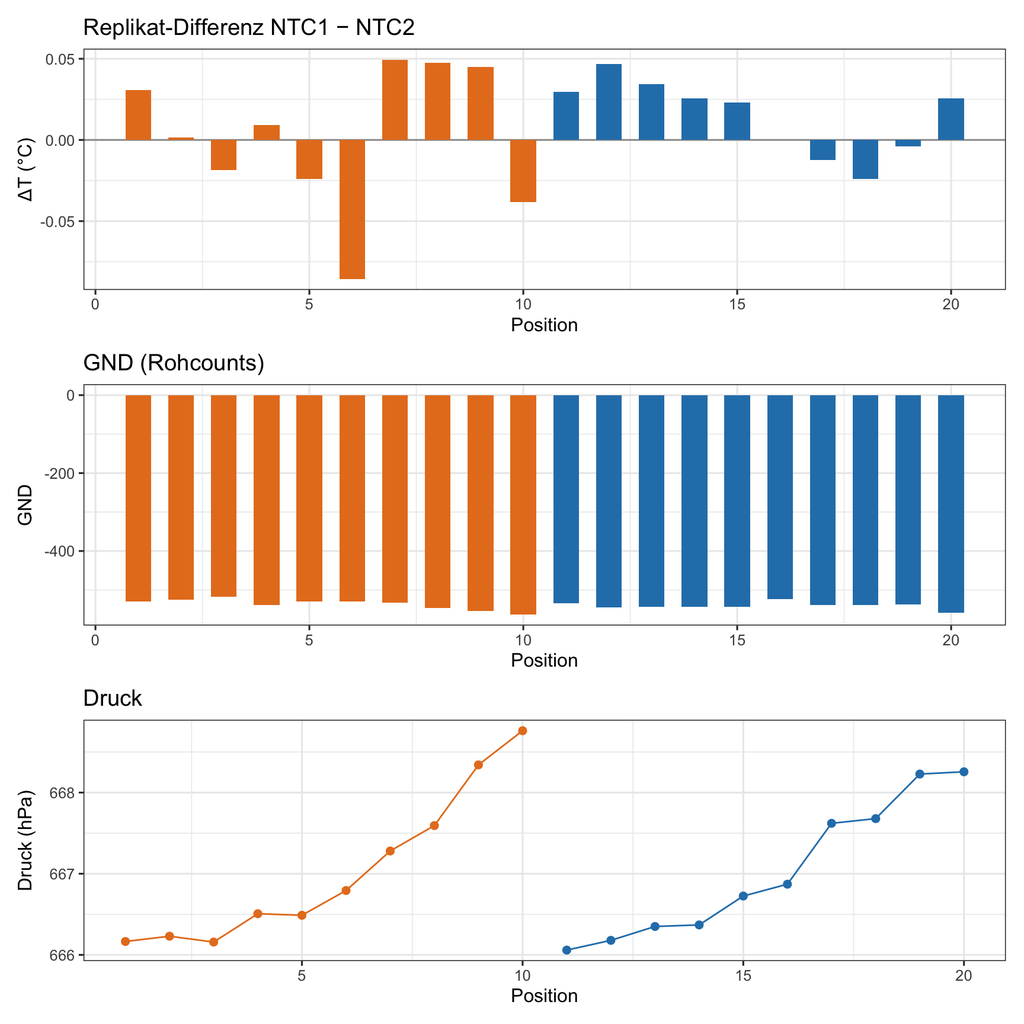

```r
# (1) Replikat-Differenz NTC1−NTC2 je Position (sollte ~0 sein).
d_rep <- nodes |> mutate(dNTC = ntc1_C - ntc2_C)
p_rep <- ggplot(d_rep, aes(position, dNTC, fill = chain)) +
  geom_hline(yintercept = 0, colour = "grey60") +
  geom_col(width = 0.6) +
  scale_fill_manual(values = c("Kette 1" = "#e67e22", "Kette 2" = "#2980b9"), guide = "none") +
  labs(title = "Replikat-Differenz NTC1 − NTC2", x = "Position", y = "ΔT (°C)") +
  theme_bw(base_size = 12)

# (2) GND (Rohcounts) je Position.
p_gnd <- ggplot(nodes, aes(position, gnd, fill = chain)) +
  geom_col(width = 0.6) +
  scale_fill_manual(values = c("Kette 1" = "#e67e22", "Kette 2" = "#2980b9"), guide = "none") +
  labs(title = "GND (Rohcounts)", x = "Position", y = "GND") +
  theme_bw(base_size = 12)

# (3) Druck je Position.
p_pr <- ggplot(nodes, aes(position, pressure_hPa, colour = chain)) +
  geom_line(aes(group = chain), linewidth = 0.5) + geom_point(size = 2) +
  scale_colour_manual(values = c("Kette 1" = "#e67e22", "Kette 2" = "#2980b9"), guide = "none") +
  labs(title = "Druck", x = "Position", y = "Druck (hPa)") +
  theme_bw(base_size = 12)

p_rep / p_gnd / p_pr
```

## Zeitlicher Verlauf

Erst **ab Nachricht -142** (Einbau in die Bohrlöcher); die früheren Nachrichten (-139…-141, Ketten noch an der Oberfläche) sind ausgeschlossen. Gezeigt wird der zeitliche Verlauf **gegenüber der Tiefe**: je Nachricht ein Tiefenprofil, Farbe = Zeit.

```r
TS_FROM_MSG <- 142L   # Zeitreihe erst ab dieser .bin-Nachricht (Einbau in Bohrlöcher)
# Nummer aus dem Dateinamen (Cloudloop-Nummerierung); Rockblock-Dateien heißen
# `-rb<datum>` und tragen keine Nummer → msg = NA. Deshalb wird die Schwelle NICHT
# über die Nummer gefiltert, sondern über die ZEIT der Nachricht -142 abgeleitet;
# so werden auch namenlose spätere Nachrichten korrekt eingeschlossen.
msg_num <- suppressWarnings(as.integer(sub(".*-(\\d+)\\.bin$", "\\1", basename(bin_files))))
times   <- unix2utc(sapply(all_bin, `[[`, "time_unix"))
ts_from_time <- if (any(msg_num == TS_FROM_MSG, na.rm = TRUE))
  min(times[which(msg_num == TS_FROM_MSG)]) else min(times)
series <- bind_rows(Map(function(b, num)
  enrich(b) |> mutate(time = unix2utc(b$time_unix), msg = num),
  all_bin, msg_num)) |>
  filter(!is.na(depth_m), time >= ts_from_time)
series$tlab <- factor(format(series$time, "%m-%d %H:%M"),
                      levels = format(sort(unique(series$time)), "%m-%d %H:%M"))
n_ts  <- length(unique(series$time))
multi <- n_ts > 1L
```

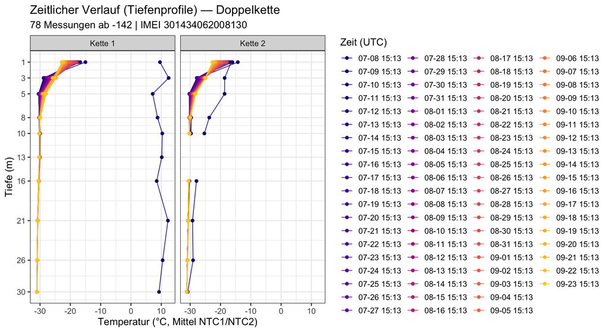

```r
# Tiefenprofil je Nachricht (Farbe = Zeit) — Entwicklung des Profils über die Zeit.
ts_depth_plot <- function(df, ttl, sub) {
  ggplot(df, aes(ntc_C, depth_m, group = time, colour = tlab)) +
    geom_path(linewidth = 0.5, alpha = 0.8) + geom_point(size = 1.6) +
    scale_y_reverse(name = "Tiefe (m)", breaks = c(1, 3, 5, 8, 10, 13, 16, 21, 26, 30)) +
    scale_x_continuous(name = "Temperatur (°C, Mittel NTC1/NTC2)") +
    scale_colour_viridis_d(name = "Zeit (UTC)", option = "C", end = 0.9, drop = FALSE) +
    facet_wrap(~ chain) +
    labs(title = ttl, subtitle = sub) +
    theme_bw(base_size = 13)
}

ts_depth_plot(series, sprintf("Zeitlicher Verlauf (Tiefenprofile) — %s", cfg$label),
              sprintf("%d Messungen ab -%d | IMEI %s", n_ts, TS_FROM_MSG, imei))
```

Zoom: **ohne den obersten Meter** (Sensor 1 m) und **ohne den ersten Datensatz** (07-08) — beide strecken sonst die Temperaturachse und verdecken die Entwicklung der tiefen, kalten Sensoren.

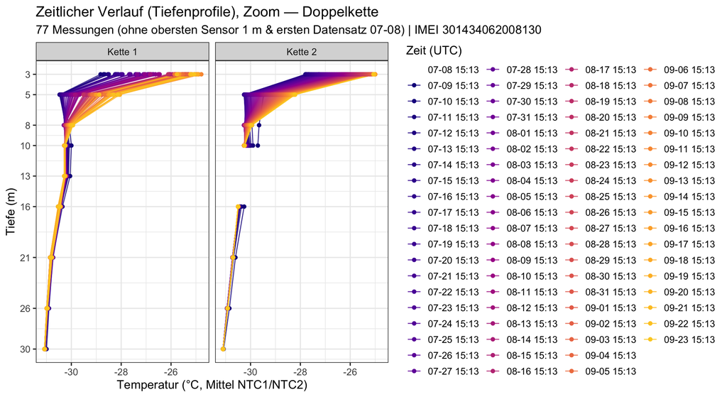

```r
series_zoom <- series |> filter(depth_m > min(depth_m), time > min(time))
n_ts_zoom   <- length(unique(series_zoom$time))

ts_depth_plot(series_zoom,
              sprintf("Zeitlicher Verlauf (Tiefenprofile), Zoom — %s", cfg$label),
              sprintf("%d Messungen (ohne obersten Sensor 1 m & ersten Datensatz 07-08) | IMEI %s",
                      n_ts_zoom, imei))
```

Dasselbe Zoom-Fenster, aber als **Anomalie gegenüber dem zeitgemittelten Profil von Kette 1**: von *beiden* Ketten wird bei jeder Tiefe das über die Zeit gemittelte Profil von **Kette 1** abgezogen (Kette 1 − Mittel(Kette 1), Kette 2 − Mittel(Kette 1)). Das linke Panel zeigt so die zeitliche Abweichung von Kette 1 vom eigenen Mittel (per Konstruktion um 0), das rechte, wie Kette 2 relativ zu diesem Referenzprofil liegt — also die Bohrloch-zu-Bohrloch-Differenz plus deren zeitliche Entwicklung.

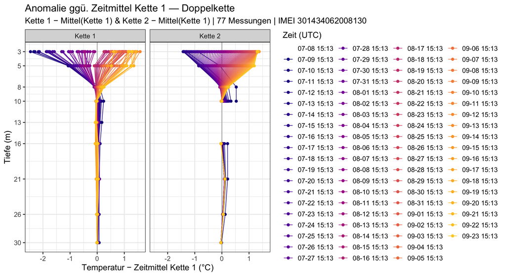

```r
# Referenz = zeitgemitteltes Tiefenprofil von KETTE 1 (gleiches Zoom-Fenster).
ref1 <- series_zoom |> filter(chain == "Kette 1") |>
  group_by(depth_m) |> summarise(ref_C = mean(ntc_C, na.rm = TRUE), .groups = "drop")

series_anom <- series_zoom |>
  left_join(ref1, by = "depth_m") |>
  mutate(anom_C = ntc_C - ref_C)

ggplot(series_anom, aes(anom_C, depth_m, group = time, colour = tlab)) +
  geom_vline(xintercept = 0, colour = "grey60", linewidth = 0.4) +
  geom_path(linewidth = 0.5, alpha = 0.8) + geom_point(size = 1.6) +
  scale_y_reverse(name = "Tiefe (m)", breaks = c(1, 3, 5, 8, 10, 13, 16, 21, 26, 30)) +
  scale_x_continuous(name = "Temperatur − Zeitmittel Kette 1 (°C)") +
  scale_colour_viridis_d(name = "Zeit (UTC)", option = "C", end = 0.9, drop = FALSE) +
  facet_wrap(~ chain) +
  labs(title = sprintf("Anomalie ggü. Zeitmittel Kette 1 — %s", cfg$label),
       subtitle = sprintf("Kette 1 − Mittel(Kette 1) & Kette 2 − Mittel(Kette 1) | %d Messungen | IMEI %s",
                          n_ts_zoom, imei)) +
  theme_bw(base_size = 13)
```

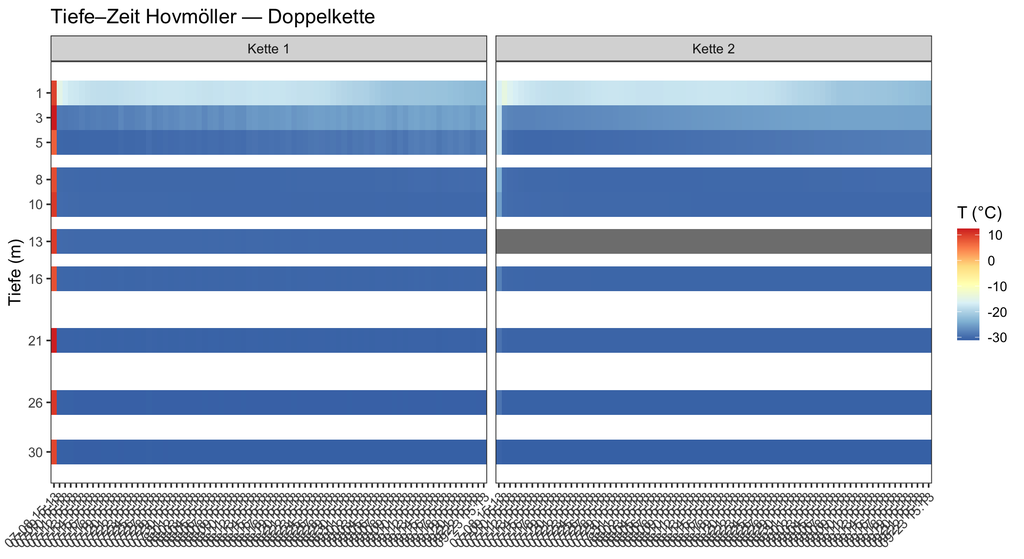

```r
# Hovmöller: Tiefe × Zeit, Farbe = Temperatur, je Kette.
tlevels <- format(sort(unique(series$time)), "%m-%d %H:%M")
hov <- series |> mutate(tlab = factor(format(time, "%m-%d %H:%M"), levels = tlevels))
ggplot(hov, aes(tlab, depth_m, fill = ntc_C)) +
  geom_tile() +
  scale_y_reverse(name = "Tiefe (m)", breaks = c(1, 3, 5, 8, 10, 13, 16, 21, 26, 30)) +
  scale_fill_distiller(palette = "RdYlBu", direction = -1, name = "T (°C)") +
  facet_wrap(~ chain) +
  labs(title = sprintf("Tiefe–Zeit Hovmöller — %s", cfg$label), x = NULL) +
  theme_bw(base_size = 13) +
  theme(axis.text.x = element_text(angle = 45, hjust = 1), panel.grid = element_blank())
```

## Zeitverläufe an festen Tiefen

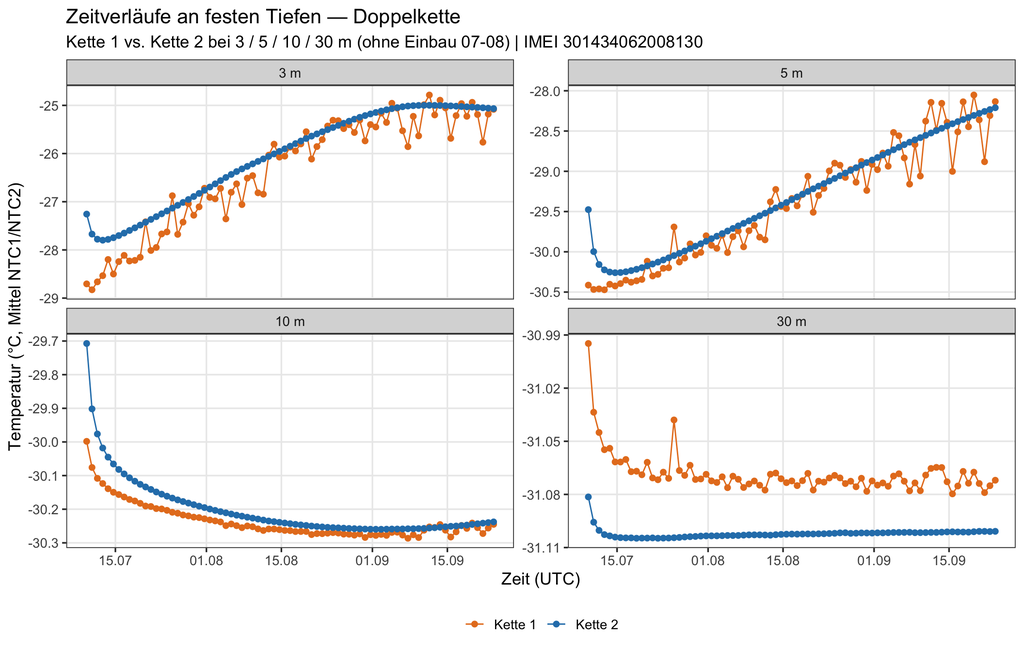

```r
FIXED_DEPTHS <- c(3, 5, 10, 30)
depth_ts <- series |>
  filter(depth_m %in% FIXED_DEPTHS, !is.na(ntc_C), time > min(time)) |>  # ohne 07-08
  mutate(depth_lab = factor(sprintf("%d m", depth_m),
                            levels = sprintf("%d m", FIXED_DEPTHS)))

ggplot(depth_ts, aes(time, ntc_C, colour = chain)) +
  geom_line(linewidth = 0.5) + geom_point(size = 1.8) +
  scale_colour_manual(values = chain_cols, name = NULL) +
  scale_x_datetime(date_labels = "%d.%m") +
  facet_wrap(~ depth_lab, scales = "free_y") +
  labs(title = sprintf("Zeitverläufe an festen Tiefen — %s", cfg$label),
       subtitle = sprintf("Kette 1 vs. Kette 2 bei 3 / 5 / 10 / 30 m (ohne Einbau 07-08) | IMEI %s", imei),
       x = "Zeit (UTC)", y = "Temperatur (°C, Mittel NTC1/NTC2)") +
  theme_bw(base_size = 13) +
  theme(legend.position = "bottom", panel.grid.minor = element_blank())
```

### Angleichung als exponentielle Relaxation (Log-Skala)

Ein frisch eingebautes Bohrloch **relaxiert exponentiell** zur Gleichgewichtstemperatur: `T(t) = T_eq + A·e^(−t/τ)`. Trägt man die **Abweichung von der Asymptote** `|T − T_eq|` halblogarithmisch auf, wird eine einfache Exponentielle zur **Geraden**, deren Steigung die Zeitkonstante τ liefert.

Der sinnvolle „Nullpunkt” der Log-Achse ist dabei **T_eq (die Asymptote), nicht 0 und nicht das Zeitmittel** — sonst wird der Logarithmus sinnlos. T_eq wird pro (Kette, Tiefe) aus einem nichtlinearen Fit `Teq + A·exp(−t/τ)` geschätzt. Das funktioniert für die **tiefen** Sensoren (klare Relaxation); der oberste (3 m) gleicht sich zuerst schnell an und wird dann von der **Oberflächenvariation** überlagert — dort knickt die Log-Kurve ab (keine reine Exponentielle mehr).

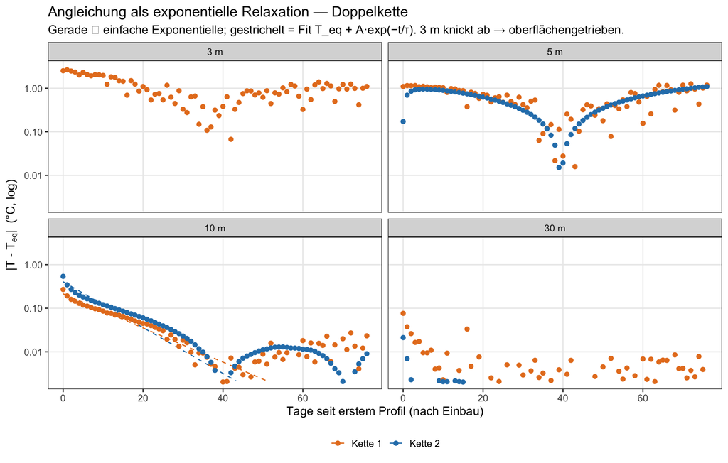

```r
relax_d <- series |>
  filter(depth_m %in% FIXED_DEPTHS, !is.na(ntc_C), time > min(time))
t0 <- min(relax_d$time)
relax_d$tdays <- as.numeric(difftime(relax_d$time, t0, units = "days"))

# Exp-Relaxation je (Kette, Tiefe); robust, tolerant gegen Nicht-Konvergenz.
grid <- seq(0, max(relax_d$tdays), length.out = 80)
fit_rows <- list(); fit_line <- list()
for (ch in unique(relax_d$chain)) for (dp in FIXED_DEPTHS) {
  g <- relax_d |> filter(chain == ch, depth_m == dp) |> arrange(tdays)
  if (nrow(g) < 4L) next
  Teq0 <- min(g$ntc_C); A0 <- max(g$ntc_C[1] - Teq0, 0.05)
  fit <- tryCatch(nls(ntc_C ~ Teq + A * exp(-k * tdays), data = g,
                      start = list(Teq = Teq0, A = A0, k = 0.7),
                      control = nls.control(maxiter = 300, warnOnly = TRUE)),
                  error = function(e) NULL)
  if (is.null(fit)) next
  co <- coef(fit); tau <- unname(1 / co["k"])
  r2 <- 1 - sum(resid(fit)^2) / sum((g$ntc_C - mean(g$ntc_C))^2)
  clean <- is.finite(tau) && tau > 0.2 && tau < 30 && r2 > 0.9 && co["A"] > 0.10
  fit_rows[[paste(ch, dp)]] <- data.frame(chain = ch, depth_m = dp,
    Teq = unname(co["Teq"]), tau = tau, r2 = r2, clean = clean)
  if (clean) fit_line[[paste(ch, dp)]] <- data.frame(chain = ch, depth_m = dp,
    tdays = grid, dep = unname(co["A"]) * exp(-grid / tau))
}
fit_tab <- bind_rows(fit_rows); fit_ln <- bind_rows(fit_line)

lv <- sprintf("%d m", FIXED_DEPTHS)
relax_p <- relax_d |> inner_join(fit_tab |> select(chain, depth_m, Teq),
                                 by = c("chain", "depth_m")) |>
  mutate(dep = abs(ntc_C - Teq),
         depth_lab = factor(sprintf("%d m", depth_m), levels = lv))
fit_ln$depth_lab <- factor(sprintf("%d m", fit_ln$depth_m), levels = lv)

ggplot(relax_p, aes(tdays, dep, colour = chain)) +
  { if (nrow(fit_ln)) geom_line(data = fit_ln, linewidth = 0.55, linetype = "dashed") } +
  geom_point(size = 2) +
  scale_y_log10(name = expression("|T - T"[eq]*"|  (°C, log)"), limits = c(2e-3, 3)) +
  scale_colour_manual(values = chain_cols, name = NULL) +
  facet_wrap(~ depth_lab) +
  labs(title = sprintf("Angleichung als exponentielle Relaxation — %s", cfg$label),
       subtitle = "Gerade ⇔ einfache Exponentielle; gestrichelt = Fit T_eq + A·exp(−t/τ). 3 m knickt ab → oberflächengetrieben.",
       x = "Tage seit erstem Profil (nach Einbau)") +
  theme_bw(base_size = 13) +
  theme(legend.position = "bottom", panel.grid.minor = element_blank())
```

```r
knitr::kable(
  fit_tab |> filter(clean) |> arrange(depth_m, chain) |>
    transmute(Kette = chain, `Tiefe (m)` = depth_m,
              `T_eq (°C)` = round(Teq, 2), `τ (Tage)` = round(tau, 2),
              `R²` = round(r2, 3)),
  caption = "Fit T_eq + A·exp(−t/τ), nur Serien mit sauberer Relaxation (τ = Zeitkonstante der Angleichung).")
```

Fit T_eq + A·exp(−t/τ), nur Serien mit sauberer Relaxation (τ = Zeitkonstante der Angleichung).

| Kette | Tiefe (m) | T_eq (°C) | τ (Tage) | R² |
| --- | --- | --- | --- | --- |
| Kette 1 | 10 | -30.27 | 11.08 | 0.945 |
| Kette 2 | 10 | -30.25 | 8.25 | 0.938 |

# Bohrloch-Experiment: Luft gegen Schnee

Beide Ketten wurden am **08.07.2026** in frisch gebohrte Löcher eingebracht, rund **10 m voneinander entfernt**, mit identischer Tiefenbelegung. **Kette 1 steht im offenen, luftgefüllten Bohrloch, Kette 2 im mit Schnee verfüllten** (Tiefentabelle: „CGB 10 Nodes in SNOW!“). Die Frage für künftige Firntemperatur-Messungen: muss das Loch verfüllt werden?

Zwei Störgrößen sind zu trennen:

- **Bohrstörung.** Beide Löcher wurden frisch gebohrt, die Ketten mit Oberflächentemperatur eingebracht. Der Firn braucht Zeit bis zum Gleichgewicht; die Angleichung ist ein Übergangsvorgang, keine Eigenschaft der Verfüllung.
- **Sensor-Offsets.** Diese Ketten laufen auf der universellen Mean-S4-Kurve, nicht auf Lab-S4 pro Sensor. Der **Mittelwert** der Differenz zweier Sensoren ist damit auf einige 10 mK unsicher. Die **Streuung einer Zeitreihe um sich selbst** ist davon nicht betroffen — deshalb ist die Tag-zu-Tag-Unruhe (A) das belastbare Kriterium, nicht die Differenz (C).

Wie groß dieser Rest ist, zeigen die **Replikate NTC1/NTC2 desselben Knotens**: sie sitzen am selben Ort, jede Differenz zwischen ihnen ist Kalibrierrest.

```r
cal_res <- series |> filter(!is.na(ntc_C), time >= max(time) - 30 * 86400) |>
  group_by(chain, depth_m) |> summarise(d_mK = mean(ntc1_C - ntc2_C) * 1000, .groups = "drop")
cat(sprintf("NTC1 - NTC2 desselben Knotens (Mean-S4-Kurve, %d Knoten): RMS %.0f mK, Spannweite %.0f bis %+.0f mK.\n",
            nrow(cal_res), sqrt(mean(cal_res$d_mK^2)), min(cal_res$d_mK), max(cal_res$d_mK)))
```

```
NTC1 - NTC2 desselben Knotens (Mean-S4-Kurve, 19 Knoten): RMS 36 mK, Spannweite -86 bis +50 mK.
```

Für diese beiden Ketten liegt **keine Lab-S4-Kalibrierung pro Sensor** vor: die Knoten-IDs (Kette 1: 34, 1, 3, 5, 6, 7, 8, 15, 16, 17; Kette 2: 33, 4, 10, 11, 12, 13, 20, 21, 22, 24) kommen in der Calibration Registry im Batch `greenland26` nicht vor — der enthält SM1/SM2 und die Nachkalibriersätze vom 06./07.07.2026. Sobald eine Kalibrierung dieser Ketten vorliegt, wird sie über `head_config$calibration` eingehängt; die Diagnostik A bleibt davon unberührt, C wird dann auf 10-mK-Niveau auswertbar.

## A · Tag-zu-Tag-Unruhe je Bohrloch

Aus den Tagesdifferenzen `T(t+1d) − T(t)` folgt die Streuung `σ_Tag = sd(ΔT)/√2`. Das Instrumentenniveau liefern die **Replikate NTC1/NTC2 desselben Knotens**: bewegen sich beide Kanäle gemeinsam, ist die Unruhe physikalisch und keine Elektronik. Ausgewertet wird das **letzte 30-Tage-Fenster**, damit die Angleichung nach dem Einbau nicht mitzählt.

```r
QUIET_DAYS <- 30
t_end  <- max(series$time)
quiet  <- series |> filter(!is.na(ntc_C), time >= t_end - QUIET_DAYS * 86400)

noise <- quiet |> arrange(chain, depth_m, time) |> group_by(chain, depth_m) |>
  mutate(dt_d = as.numeric(difftime(time, lag(time), units = "days")),
         dT   = ntc_C - lag(ntc_C)) |>
  filter(!is.na(dT), dt_d > 0.5, dt_d < 1.5) |>
  summarise(n = n(),
            sd_day  = sd(dT) / sqrt(2) * 1000,
            sd_repl = sd(ntc1_C - ntc2_C, na.rm = TRUE) / sqrt(2) * 1000,
            .groups = "drop")

knitr::kable(
  noise |> select(chain, depth_m, n, sd_day, sd_repl) |>
    tidyr::pivot_wider(id_cols = depth_m, names_from = chain,
                       values_from = c(sd_day, sd_repl)) |> arrange(depth_m) |>
    (\(d) transmute(d, `Tiefe (m)` = depth_m,
        `Luft: σ_Tag (mK)`   = round(`sd_day_Kette 1`, 1),
        `Schnee: σ_Tag (mK)` = round(`sd_day_Kette 2`, 1),
        `Verhältnis`         = round(`sd_day_Kette 1` / `sd_day_Kette 2`, 1),
        `Luft: Replikat (mK)`   = round(`sd_repl_Kette 1`, 1),
        `Schnee: Replikat (mK)` = round(`sd_repl_Kette 2`, 1)))(),
  caption = sprintf("Tag-zu-Tag-Streuung der letzten %d Tage, gegen das Replikat-Rauschen desselben Knotens.", QUIET_DAYS))
```

Tag-zu-Tag-Streuung der letzten 30 Tage, gegen das Replikat-Rauschen desselben Knotens.

| Tiefe (m) | Luft: σ_Tag (mK) | Schnee: σ_Tag (mK) | Verhältnis | Luft: Replikat (mK) | Schnee: Replikat (mK) |
| --- | --- | --- | --- | --- | --- |
| 1 | 76.7 | 69.3 | 1.1 | 2.4 | 3.0 |
| 3 | 260.6 | 13.7 | 19.0 | 3.1 | 0.5 |
| 5 | 252.6 | 2.3 | 111.5 | 4.4 | 0.2 |
| 8 | 26.3 | 0.9 | 29.8 | 0.3 | 0.1 |
| 10 | 8.1 | 0.7 | 12.2 | 0.1 | 0.1 |
| 13 | 8.9 | NA | NA | 0.2 | NA |
| 16 | 26.9 | 0.1 | 230.2 | 0.8 | 0.0 |
| 21 | 20.2 | 0.1 | 207.6 | 0.5 | 0.2 |
| 26 | 9.2 | 0.1 | 99.4 | 0.2 | 0.1 |
| 30 | 3.6 | 0.1 | 40.6 | 0.0 | 0.1 |

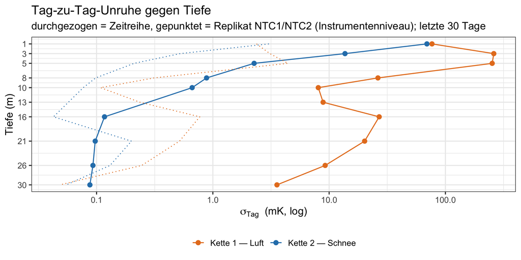

```r
ggplot(noise, aes(sd_day, depth_m, colour = chain)) +
  geom_path(linewidth = 0.6) + geom_point(size = 2.4) +
  geom_path(aes(sd_repl, depth_m, group = chain), linetype = "dotted", linewidth = 0.5) +
  scale_x_log10(name = expression(sigma[Tag]*"  (mK, log)")) +
  scale_y_reverse(name = "Tiefe (m)", breaks = c(1, 3, 5, 8, 10, 13, 16, 21, 26, 30)) +
  scale_colour_manual(values = chain_cols, name = NULL,
                      labels = c("Kette 1 — Luft", "Kette 2 — Schnee")) +
  labs(title = "Tag-zu-Tag-Unruhe gegen Tiefe",
       subtitle = sprintf("durchgezogen = Zeitreihe, gepunktet = Replikat NTC1/NTC2 (Instrumentenniveau); letzte %d Tage", QUIET_DAYS)) +
  theme_bw(base_size = 13) + theme(legend.position = "bottom")
```

## B · Zwei tiefe Sensoren im Detail

Bei 21 und 30 m ist die Firntemperatur physikalisch träge: die Jahreswelle hat dort eine Amplitude von wenigen 10 mK und eine Zeitskala von Monaten, eine Tagesänderung von mehr als 1 mK ist ausgeschlossen. Was schneller schwankt, kommt nicht aus dem Firn.

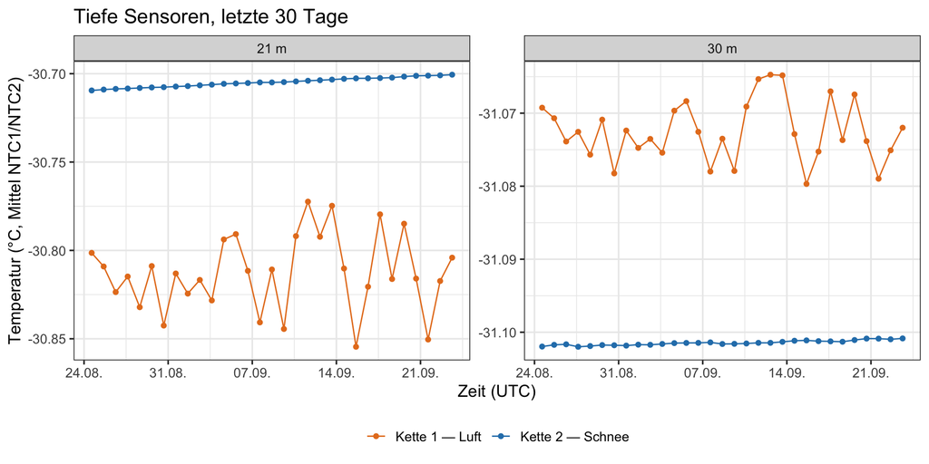

```r
deep_ex <- series |> filter(depth_m %in% c(21, 30), !is.na(ntc_C),
                            time >= t_end - QUIET_DAYS * 86400) |>
  mutate(depth_lab = sprintf("%d m", depth_m))

ggplot(deep_ex, aes(time, ntc_C, colour = chain)) +
  geom_line(linewidth = 0.5) + geom_point(size = 1.5) +
  scale_colour_manual(values = chain_cols, name = NULL,
                      labels = c("Kette 1 — Luft", "Kette 2 — Schnee")) +
  scale_x_datetime(date_labels = "%d.%m.") +
  facet_wrap(~ depth_lab, scales = "free_y") +
  labs(title = "Tiefe Sensoren, letzte 30 Tage", x = "Zeit (UTC)",
       y = "Temperatur (°C, Mittel NTC1/NTC2)") +
  theme_bw(base_size = 13) + theme(legend.position = "bottom")
```

```r
knitr::kable(
  deep_ex |> group_by(chain, depth_m) |>
    summarise(`Spannweite (mK)` = round(diff(range(ntc_C)) * 1000, 1),
              `mittlere Drift (mK/d)` = round(coef(lm(ntc_C ~ as.numeric(time)))[2] * 86400 * 1000, 2),
              `NTC1−NTC2 (mK)` = round(mean(ntc1_C - ntc2_C) * 1000, 1),
              `dessen sd (mK)` = round(sd(ntc1_C - ntc2_C) * 1000, 1), .groups = "drop") |>
    rename(Kette = chain, `Tiefe (m)` = depth_m),
  caption = "Konstante Replikat-Differenz bei schwankender Temperatur = beide NTC-Kanäle bewegen sich gemeinsam; die Schwankung ist keine Sensorstörung.")
```

Konstante Replikat-Differenz bei schwankender Temperatur = beide NTC-Kanäle bewegen sich gemeinsam; die Schwankung ist keine Sensorstörung.

| Kette | Tiefe (m) | Spannweite (mK) | mittlere Drift (mK/d) | NTC1−NTC2 (mK) | dessen sd (mK) |
| --- | --- | --- | --- | --- | --- |
| Kette 1 | 21 | 82.1 | 0.25 | 47.9 | 0.7 |
| Kette 1 | 30 | 15.0 | 0.01 | -38.2 | 0.1 |
| Kette 2 | 21 | 8.9 | 0.29 | -23.6 | 0.3 |
| Kette 2 | 30 | 1.1 | 0.03 | 25.5 | 0.1 |

## C · Angleichung der beiden Bohrlöcher

`ΔT(z,t) = T_Luft − T_Schnee` bei gleicher Tiefe. Der Übergangsanteil ist die unterschiedliche Erholung von der Bohrung, der Endwert enthält den Bohrloch-Effekt **und** den Kalibrier-Offset der Sensorpaare — deshalb nur als Größenordnung zu lesen.

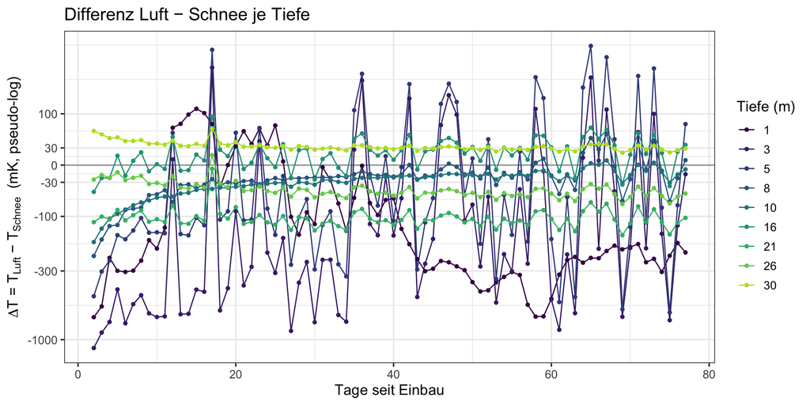

```r
# Der Einbautag selbst (Ketten noch oberflächenwarm, ΔT über 10 K) bleibt außen vor.
dTs <- series |> filter(!is.na(ntc_C)) |>
  select(time, chain, depth_m, ntc_C) |>
  tidyr::pivot_wider(names_from = chain, values_from = ntc_C) |>
  filter(!is.na(`Kette 1`), !is.na(`Kette 2`)) |>
  mutate(dT = `Kette 1` - `Kette 2`,
         td = as.numeric(difftime(time, min(time), units = "days"))) |>
  filter(td >= 1)

ggplot(dTs, aes(td, dT * 1000, colour = factor(depth_m))) +
  geom_hline(yintercept = 0, colour = "grey60") +
  geom_line(linewidth = 0.5) + geom_point(size = 1.2) +
  scale_colour_viridis_d(name = "Tiefe (m)", option = "D", end = 0.9) +
  scale_y_continuous(trans = scales::pseudo_log_trans(sigma = 50),
                     breaks = c(-1000, -300, -100, -30, 0, 30, 100)) +
  labs(title = "Differenz Luft − Schnee je Tiefe", x = "Tage seit Einbau",
       y = expression(Delta*"T = T"[Luft]*" − T"[Schnee]*"  (mK, pseudo-log)")) +
  theme_bw(base_size = 13)
```

Statt einer Zeitkonstanten aus einem Exponentialfit — die Angleichung ist keine reine Exponentielle — wird direkt abgelesen, **ab wann ΔT innerhalb von 100 bzw. 30 mK um seinen Endwert liegt** (Endwert = Mittel der letzten zehn Tage).

```r
dt_tab <- bind_rows(lapply(split(dTs, dTs$depth_m), function(g) {
  g <- g[order(g$td), ]
  ende <- mean(tail(g$dT, 10))
  hit  <- function(tol) { ok <- abs(g$dT - ende) < tol
    j <- which(ok & !rev(cumsum(rev(!ok)) > 0))          # ab hier dauerhaft innerhalb
    if (length(j)) g$td[min(j)] else NA_real_ }
  data.frame(depth_m = g$depth_m[1], start = g$dT[1] * 1000, ende = ende * 1000,
             t100 = hit(0.100), t30 = hit(0.030))
}))

knitr::kable(dt_tab |> transmute(`Tiefe (m)` = depth_m,
    `ΔT nach 1 Tag (mK)` = round(start, 0), `ΔT letzte 10 Tage (mK)` = round(ende, 0),
    `dauerhaft <100 mK (Tage)` = round(t100, 0), `dauerhaft <30 mK (Tage)` = round(t30, 0)),
  caption = "Angleichung der beiden Bohrlöcher: Tage nach Einbau, ab denen ΔT dauerhaft innerhalb der Toleranz um seinen Endwert bleibt.")
```

Angleichung der beiden Bohrlöcher: Tage nach Einbau, ab denen ΔT dauerhaft innerhalb der Toleranz um seinen Endwert bleibt.

| Tiefe (m) | ΔT nach 1 Tag (mK) | ΔT letzte 10 Tage (mK) | dauerhaft <100 mK (Tage) | dauerhaft <30 mK (Tage) |
| --- | --- | --- | --- | --- |
| 1 | -678 | -218 | 62 | 77 |
| 3 | -1155 | -195 | NA | NA |
| 5 | -470 | -102 | NA | NA |
| 8 | -228 | -11 | 6 | 76 |
| 10 | -174 | -13 | 4 | 16 |
| 16 | -48 | 19 | 2 | 76 |
| 21 | -114 | -114 | 18 | 76 |
| 26 | -25 | -55 | 2 | 18 |
| 30 | 62 | 27 | 2 | 18 |

## D · Zusammenhang mit Wind und Schichtung

Getestet wird, ob die Unruhe im Luftloch einem äußeren Antrieb folgt: Windgeschwindigkeit der Summit-AWS (~30 km) und Schichtung der Luftsäule im Loch (`T(1 m) − T(30 m)`; positiv = oben wärmer = stabil, freie Konvektion unterdrückt).

```r
aws_d <- tryCatch({ options(timeout = 60)
  suppressWarnings(readr::read_csv(
    "https://thredds.geus.dk/thredds/fileServer/aws/l3sites/csv/day/SUM_day.csv",
    show_col_types = FALSE)) |> mutate(day = as.Date(time)) |>
    select(day, wspd = wspd_u, t_air = t_u, p_aws = p_u) },
  error = function(e) NULL)

drv <- series |> filter(!is.na(ntc_C), depth_m >= 16,
                        time >= t_end - QUIET_DAYS * 86400) |>
  arrange(chain, depth_m, time) |> group_by(chain, depth_m) |>
  mutate(dT_day = abs(ntc_C - lag(ntc_C))) |> ungroup() |>
  filter(!is.na(dT_day)) |>
  group_by(chain, day = as.Date(time)) |> summarise(unruhe = mean(dT_day) * 1000, .groups = "drop")

strat <- series |> filter(depth_m %in% c(1, 30), !is.na(ntc_C),
                          time >= t_end - QUIET_DAYS * 86400) |>
  group_by(day = as.Date(time), depth_m) |> summarise(t = mean(ntc_C), .groups = "drop") |>
  tidyr::pivot_wider(names_from = depth_m, values_from = t, names_prefix = "d") |>
  mutate(schichtung = d1 - d30)

if (!is.null(aws_d)) {
  dd <- drv |> left_join(strat, by = "day") |> left_join(aws_d, by = "day")
  knitr::kable(
    dd |> group_by(Kette = chain) |>
      summarise(`Tage` = sum(is.finite(unruhe)),
                `mittlere Unruhe (mK/d)` = round(mean(unruhe, na.rm = TRUE), 1),
                `r(Wind)` = round(cor(unruhe, wspd, use = "complete.obs"), 2),
                `r(Schichtung)` = round(cor(unruhe, schichtung, use = "complete.obs"), 2),
                `Schichtung (K)` = round(mean(schichtung, na.rm = TRUE), 1)),
    caption = sprintf("Tagesunruhe der Sensoren ab 16 m im ruhigen Fenster (letzte %d Tage) gegen Wind und Schichtung der Luftsäule.", QUIET_DAYS))
} else cat("Summit-AWS nicht erreichbar — Abschnitt D übersprungen.\n")
```

Tagesunruhe der Sensoren ab 16 m im ruhigen Fenster (letzte 30 Tage) gegen Wind und Schichtung der Luftsäule.

| Kette | Tage | mittlere Unruhe (mK/d) | r(Wind) | r(Schichtung) | Schichtung (K) |
| --- | --- | --- | --- | --- | --- |
| Kette 1 | 30 | 18.5 | 0.13 | -0.48 | 10.1 |
| Kette 2 | 30 | 0.2 | -0.01 | 0.41 | 10.1 |

## E · Auslegung: wie tief muss verfüllt werden?

Verfüllen kostet Zeit und Material, und zwar mit der Lochlänge. Die Frage ist deshalb nicht „Luft oder Schnee”, sondern **ab welcher Tiefe die Unruhe des Luftlochs für das jeweilige Ziel klein genug ist**. Entscheidend dafür ist nicht σ_Tag allein, sondern ob sich die Unruhe **wegmitteln** lässt.

```r
STRUCT_DAYS <- 45
st <- series |> filter(!is.na(ntc_C), time >= t_end - STRUCT_DAYS * 86400)

struct <- bind_rows(lapply(split(st, list(st$chain, st$depth_m), drop = TRUE), function(x) {
  x <- x[order(x$time), ]; if (nrow(x) < 20) return(NULL)
  x$td <- as.numeric(difftime(x$time, min(x$time), units = "days"))
  r <- resid(loess(ntc_C ~ td, data = x, span = 0.5))
  blk <- tapply(r, cut(seq_along(r), ceiling(length(r) / 10)), mean)
  data.frame(chain = x$chain[1], depth_m = x$depth_m[1],
             sigma = sd(r) * 1000, acf1 = acf(r, plot = FALSE, lag.max = 1)$acf[2],
             sd_blk = sd(blk) * 1000, sd_mon = sd(r) * 1000 / sqrt(30))
}))

# Signal: gemessene Änderung der verfüllten Kette über das Fenster, je Tiefe
sig <- st |> filter(chain == "Kette 2") |> arrange(depth_m, time) |> group_by(depth_m) |>
  summarise(signal = abs(mean(tail(ntc_C, 3)) - mean(head(ntc_C, 3))) * 1000, .groups = "drop")

# Dämpfungslänge der Saisonwelle aus denselben Amplituden (3–16 m)
dfit <- lm(log(signal) ~ depth_m, data = sig |> filter(depth_m >= 3, depth_m <= 16, signal > 0))
d_ann <- -1 / coef(dfit)[2]

knitr::kable(
  struct |> filter(chain == "Kette 1") |> left_join(sig, by = "depth_m") |>
    mutate(saison = exp(predict(dfit, newdata = data.frame(depth_m = depth_m)))) |>
    transmute(`Tiefe (m)` = depth_m,
              `Änderung 6 Wochen (mK)` = round(signal, 0),
              `Saisonwelle erwartet (mK)` = round(saison, 1),
              `σ_Tag Luft (mK)` = round(sigma, 1),
              `ACF(1 Tag)` = round(acf1, 2),
              `σ 30-Tage-Mittel (mK)` = round(sd_mon, 1),
              `σ Jahresmittel (mK)` = round(sigma / sqrt(365), 2)),
  caption = sprintf("Luftloch: Rauschstruktur der letzten %d Tage. Spalte 2 ist die gemessene Änderung im verfüllten Loch (ab 16 m Restrelaxation, kein Saisonsignal), Spalte 3 die aus der Dämpfungslänge extrapolierte Saisonwelle.", STRUCT_DAYS))
```

Luftloch: Rauschstruktur der letzten 45 Tage. Spalte 2 ist die gemessene Änderung im verfüllten Loch (ab 16 m Restrelaxation, kein Saisonsignal), Spalte 3 die aus der Dämpfungslänge extrapolierte Saisonwelle.

| Tiefe (m) | Änderung 6 Wochen (mK) | Saisonwelle erwartet (mK) | σ_Tag Luft (mK) | ACF(1 Tag) | σ 30-Tage-Mittel (mK) | σ Jahresmittel (mK) |
| --- | --- | --- | --- | --- | --- | --- |
| 1 | 4549 | 3003.1 | 88.7 | 0.66 | 16.2 | 4.64 |
| 3 | 1104 | 1309.2 | 252.3 | 0.04 | 46.1 | 13.20 |
| 5 | 1319 | 570.7 | 222.7 | 0.00 | 40.7 | 11.66 |
| 8 | 292 | 164.3 | 23.6 | 0.16 | 4.3 | 1.24 |
| 10 | 10 | 71.6 | 7.6 | 0.23 | 1.4 | 0.40 |
| 13 | NA | 20.6 | 8.7 | 0.05 | 1.6 | 0.46 |
| 16 | 12 | 5.9 | 24.6 | -0.02 | 4.5 | 1.29 |
| 21 | 14 | 0.7 | 18.9 | 0.03 | 3.5 | 0.99 |
| 26 | 10 | 0.1 | 8.7 | 0.05 | 1.6 | 0.46 |
| 30 | 2 | 0.0 | 3.6 | 0.13 | 0.7 | 0.19 |

```r
cat(sprintf("\nDämpfungslänge aus den Amplituden 3–16 m: d = %.1f m (R² = %.2f).\n",
            d_ann, summary(dfit)$r.squared))
```

```
Dämpfungslänge aus den Amplituden 3–16 m: d = 2.4 m (R² = 0.77).
```

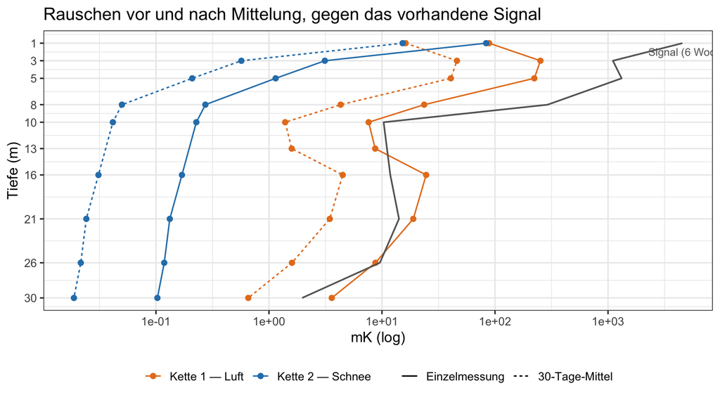

```r
struct |> select(chain, depth_m, sigma, sd_mon) |>
  tidyr::pivot_longer(c(sigma, sd_mon), names_to = "was", values_to = "mK") |>
  mutate(was = factor(was, c("sigma", "sd_mon"), c("Einzelmessung", "30-Tage-Mittel"))) |>
  ggplot(aes(mK, depth_m, colour = chain, linetype = was)) +
  geom_path(linewidth = 0.6) + geom_point(size = 2) +
  geom_path(data = sig, aes(signal, depth_m), inherit.aes = FALSE,
            colour = "grey40", linewidth = 0.7) +
  annotate("text", x = max(sig$signal) * 0.5, y = 2, label = "Signal (6 Wochen)",
           colour = "grey40", size = 3.4, hjust = 0) +
  scale_x_log10(name = "mK (log)") +
  scale_y_reverse(name = "Tiefe (m)", breaks = c(1, 3, 5, 8, 10, 13, 16, 21, 26, 30)) +
  scale_colour_manual(values = chain_cols, name = NULL,
                      labels = c("Kette 1 — Luft", "Kette 2 — Schnee")) +
  scale_linetype_manual(values = c("solid", "22"), name = NULL) +
  labs(title = "Rauschen vor und nach Mittelung, gegen das vorhandene Signal") +
  theme_bw(base_size = 13) + theme(legend.position = "bottom")
```

Nicht aus diesen Daten zu bestimmen ist ein **systematischer** Versatz des Luftlochs. Die gemessene Restdifferenz beider Löcher unterhalb 8 m (14–110 mK) liegt im Bereich der Kalibrierreste der Mean-S4-Kurve; ein tiefenabhängiger Versatz des Luftlochs in dieser Größenordnung lässt sich damit **nicht ausschließen**. Für Gradienten-Auswertungen ist das die relevante Restunsicherheit, nicht das Rauschen.

**Vorschlag für die Auslegung**

- **Tiefes Loch in Luft, Sensoren erst ab ~8–10 m.** Oberhalb bringt es nichts, unterhalb reicht es für Monats- und Jahresmittel. Das Verfüllen entfällt dort, wo es am meisten Material und Zeit kostet.
- **Flaches Loch (10–20 m) verfüllt**, mit der dichten Sensorbelegung der obersten Meter. Dort sitzt das schnelle Signal, dort ist Verfüllen billig: bei 5 cm Lochradius sind 20 m rund 0,16 m³ ≈ 60 kg Schnee, 30 m wären 0,24 m³ ≈ 90 kg.
- **Überlappung 10–16 m in beiden Löchern.** Das ist der Teil, den man nicht weglassen sollte: nur dort lässt sich ein systematischer Versatz des Luftlochs überhaupt messen und das tiefe Profil an das verfüllte anbinden.
- **Lab-S4-Kalibrierung pro Sensor** für beide Ketten. Ohne sie bleibt der Versatz zwischen den Löchern bei ~40 mK stecken, unabhängig davon, wie lange gemessen wird.

## Einordnung und Empfehlung

Die Literatur zu luftgefüllten Bohrlöchern deckt sich mit dem Befund: flache, luftgefüllte Löcher gelten als anfällig für konvektive Durchmischung, weshalb Bohrlöcher und Schächte für Firntemperaturmessungen mit Bohrklein und lockerem Schnee verfüllt werden — um die Störung des Firns gering zu halten und den Wärmekontakt herzustellen ([Zhang et al., Law Dome](https://www.cambridge.org/core/journals/annals-of-glaciology/article/nearsurface-temperatures-in-the-dome-summit-south-law-dome-east-antarctica-borehole/BA3F7D8F8A848B9FCFDB0BE64341C58D); [Brandt & Warren, South Pole](https://www.cambridge.org/core/journals/journal-of-glaciology/article/temperature-measurements-and-heat-transfer-in-nearsurface-snow-at-the-south-pole/72AE1533ABE19467FB56442091F81105); [Marchenko et al., Lomonosovfonna](https://tc.copernicus.org/articles/13/1843/2019/)).

**Die Bohrstörung ist hier eine andere als in der Bohrloch-Literatur.** Die Erholungszeiten dort — Stunden bis Tage im Firn, Monate in warmem Eis — gelten für **thermisches** Bohren mit Schmelzwasser und Wiedergefrieren ([Talalay et al.](https://doi.org/10.3390/w16233460)). **Trocken mechanisch gebohrt** entfällt dieser Eintrag; die Reibungswärme des Bohrers ist gegen die Wärmekapazität des Firns vernachlässigbar. Übrig bleiben drei Beiträge, alle Massen- statt Prozesswärme:

- die **oberflächenwarm eingebrachte Kette** samt Kabel,
- die **Durchlüftung des offenen Lochs** mit Oberflächenluft während des Bohrens,
- im verfüllten Loch der **Verfüllschnee selbst**, der mit Oberflächentemperatur eingebracht wird und pro Meter die mit Abstand größte Masse stellt.

Für die Planung folgt daraus: **verfüllen**. Die Kosten des offenen Lochs sind nicht der Mittelwert — der stimmt nach der Angleichung in beiden Löchern —, sondern die dauerhafte Tagesunruhe, die im Firn kein Gegenstück hat und jede Auswertung auf mK-Niveau limitiert.

# Druck: barometrisches Signal oder Firn-Pumping?

Jeder Knoten misst den Druck. Die Frage ist, ob der Schnee um die Sensoren die Fluktuationen verändert und woher sie kommen.

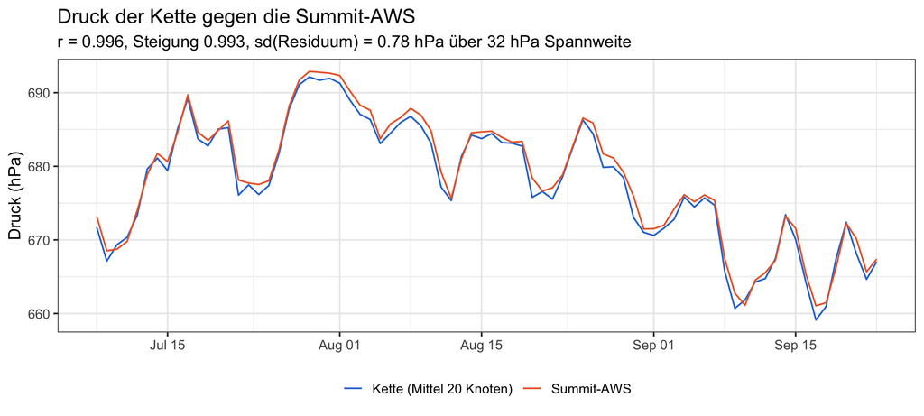

```r
p_node <- series |> filter(!is.na(pressure_hPa))
p_common <- p_node |> group_by(time) |> summarise(p_chain = mean(pressure_hPa), .groups = "drop") |>
  mutate(day = as.Date(time))

if (!is.null(aws_d)) {
  pc <- p_common |> left_join(aws_d, by = "day") |> filter(is.finite(p_aws))
  fitp <- lm(p_chain ~ p_aws, pc)
  ggplot(pc, aes(day)) +
    geom_line(aes(y = p_chain, colour = "Kette (Mittel 20 Knoten)"), linewidth = 0.6) +
    geom_line(aes(y = p_aws,   colour = "Summit-AWS"), linewidth = 0.6) +
    scale_colour_manual(values = c("Kette (Mittel 20 Knoten)" = "#2a78d6",
                                   "Summit-AWS" = "#eb6834"), name = NULL) +
    labs(title = "Druck der Kette gegen die Summit-AWS", x = NULL, y = "Druck (hPa)",
         subtitle = sprintf("r = %.3f, Steigung %.3f, sd(Residuum) = %.2f hPa über %.0f hPa Spannweite",
                            cor(pc$p_chain, pc$p_aws), coef(fitp)[2], sd(resid(fitp)),
                            diff(range(pc$p_aws)))) +
    theme_bw(base_size = 13) + theme(legend.position = "bottom")
}
```

Der Vergleich der beiden Bohrlöcher braucht einen Bezug **innerhalb** derselben Kette, sonst schlägt ein Signal der einen Kette mit umgekehrtem Vorzeichen in die andere durch. Verwendet wird deshalb die **interne Luftsäule** `Δp(z) = p(z) − p(1 m)` derselben Kette. Erwartet wird der hydrostatische Gradient `ρg ≈ 9.5 Pa/m` (ρ ≈ 0,97 kg/m³ bei 675 hPa, −30 °C).

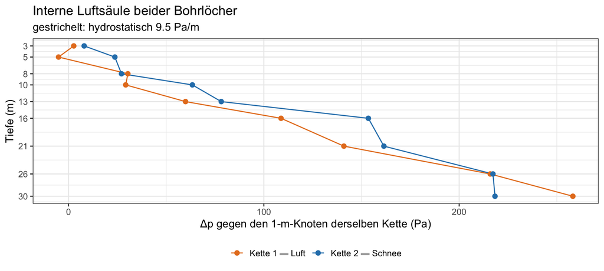

```r
p_top <- p_node |> filter(depth_m == min(depth_m)) |>
  select(time, chain, p_top = pressure_hPa)
p_col <- p_node |> left_join(p_top, by = c("time", "chain")) |>
  mutate(dp_Pa = (pressure_hPa - p_top) * 100)

# Statistik im ruhigen Fenster: die Einbautage tragen sonst die Angleichung der
# Sensortemperaturen in die Druckstreuung hinein.
p_col_q <- p_col |> filter(time >= t_end - QUIET_DAYS * 86400, depth_m > min(depth_m))

col_stat <- p_col_q |> group_by(chain, depth_m) |>
  summarise(mittel = mean(dp_Pa), streu = sd(dp_Pa), .groups = "drop")

ggplot(col_stat, aes(mittel, depth_m, colour = chain)) +
  geom_abline(slope = 1 / 9.5, intercept = 1, linetype = "dashed", colour = "grey50") +
  geom_path(linewidth = 0.6) + geom_point(size = 2.4) +
  scale_y_reverse(name = "Tiefe (m)", breaks = c(1, 3, 5, 8, 10, 13, 16, 21, 26, 30)) +
  scale_x_continuous(name = "Δp gegen den 1-m-Knoten derselben Kette (Pa)") +
  scale_colour_manual(values = chain_cols, name = NULL,
                      labels = c("Kette 1 — Luft", "Kette 2 — Schnee")) +
  labs(title = "Interne Luftsäule beider Bohrlöcher",
       subtitle = "gestrichelt: hydrostatisch 9.5 Pa/m") +
  theme_bw(base_size = 13) + theme(legend.position = "bottom")
```

```r
p_day <- p_col_q |> arrange(chain, depth_m, time) |>
  group_by(chain, depth_m) |>
  mutate(dt_d = as.numeric(difftime(time, lag(time), units = "days")),
         d_dp = dp_Pa - lag(dp_Pa)) |>
  filter(!is.na(d_dp), dt_d > 0.5, dt_d < 1.5) |>
  summarise(tag_zu_tag = sd(d_dp) / sqrt(2), .groups = "drop")

knitr::kable(
  col_stat |> left_join(p_day, by = c("chain", "depth_m")) |>
    tidyr::pivot_wider(id_cols = depth_m, names_from = chain,
                       values_from = c(mittel, streu, tag_zu_tag)) |> arrange(depth_m) |>
    (\(d) transmute(d, `Tiefe (m)` = depth_m,
        `Δp Luft (Pa)`   = round(`mittel_Kette 1`, 0),
        `Δp Schnee (Pa)` = round(`mittel_Kette 2`, 0),
        `Streuung Luft (Pa)`   = round(`streu_Kette 1`, 1),
        `Streuung Schnee (Pa)` = round(`streu_Kette 2`, 1),
        `σ_Tag Luft (Pa)`   = round(`tag_zu_tag_Kette 1`, 1),
        `σ_Tag Schnee (Pa)` = round(`tag_zu_tag_Kette 2`, 1)))(),
  caption = sprintf("Interne Luftsäule je Kette im ruhigen Fenster (letzte %d Tage): Mittelwert, zeitliche Streuung und Tag-zu-Tag-Streuung.", QUIET_DAYS))
```

Interne Luftsäule je Kette im ruhigen Fenster (letzte 30 Tage): Mittelwert, zeitliche Streuung und Tag-zu-Tag-Streuung.

| Tiefe (m) | Δp Luft (Pa) | Δp Schnee (Pa) | Streuung Luft (Pa) | Streuung Schnee (Pa) | σ_Tag Luft (Pa) | σ_Tag Schnee (Pa) |
| --- | --- | --- | --- | --- | --- | --- |
| 3 | 3 | 8 | 2.1 | 3.2 | 0.8 | 0.4 |
| 5 | -5 | 24 | 2.5 | 3.5 | 0.8 | 0.4 |
| 8 | 30 | 27 | 2.1 | 2.5 | 0.8 | 0.5 |
| 10 | 29 | 63 | 1.9 | 2.1 | 0.8 | 0.6 |
| 13 | 60 | 78 | 1.9 | 1.8 | 0.9 | 0.6 |
| 16 | 109 | 154 | 2.0 | 1.6 | 1.0 | 0.7 |
| 21 | 141 | 161 | 2.1 | 1.4 | 1.2 | 0.9 |
| 26 | 216 | 217 | 2.5 | 1.5 | 1.4 | 1.0 |
| 30 | 258 | 218 | 2.6 | 1.6 | 1.5 | 1.2 |

```r
if (!is.null(aws_d)) {
  pw <- p_col_q |> filter(depth_m == max(depth_m)) |> mutate(day = as.Date(time)) |>
    left_join(aws_d, by = "day") |> arrange(chain, time) |> group_by(chain) |>
    mutate(d_dp = dp_Pa - lag(dp_Pa), d_w = wspd - lag(wspd)) |>
    filter(!is.na(d_dp), !is.na(d_w))
  knitr::kable(
    pw |> summarise(n = n(),
        `sd Tagesänderung (Pa)` = round(sd(d_dp), 1),
        `r(ΔWind)` = round(cor(d_dp, d_w), 2),
        `p-Wert` = signif(cor.test(d_dp, d_w)$p.value, 2)) |> rename(Kette = chain),
    caption = "Tagesänderung der 30-m-Säule gegen die Tagesänderung der Windgeschwindigkeit (Windpumpen-Test).")
}
```

Tagesänderung der 30-m-Säule gegen die Tagesänderung der Windgeschwindigkeit (Windpumpen-Test).

| Kette | n | sd Tagesänderung (Pa) | r(ΔWind) | p-Wert |
| --- | --- | --- | --- | --- |
| Kette 1 | 24 | 2.2 | -0.04 | 0.840 |
| Kette 2 | 24 | 1.5 | 0.35 | 0.098 |

## Zeitreihen gegen Tiefe

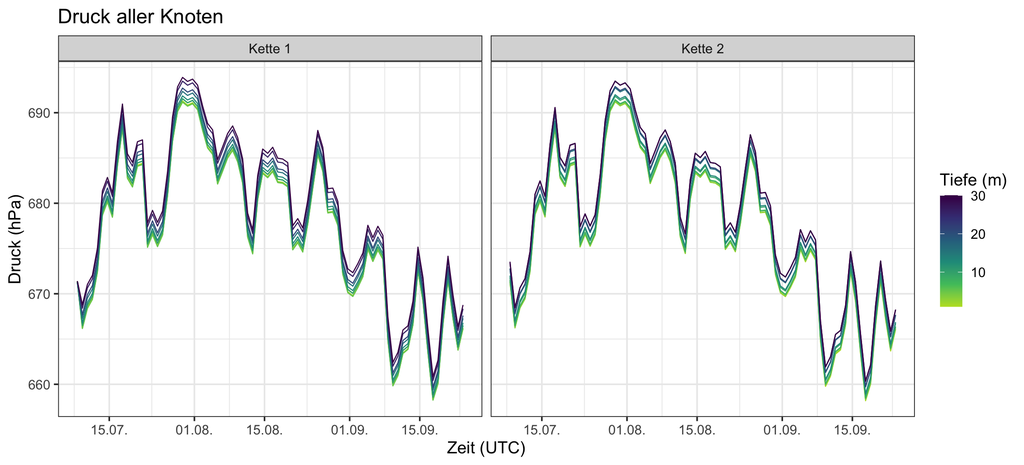

```r
ggplot(p_node, aes(time, pressure_hPa, colour = depth_m, group = interaction(chain, depth_m))) +
  geom_line(linewidth = 0.4) +
  scale_colour_viridis_c(name = "Tiefe (m)", option = "D", end = 0.9, direction = -1) +
  scale_x_datetime(date_labels = "%d.%m.") +
  facet_wrap(~ chain) +
  labs(title = "Druck aller Knoten", x = "Zeit (UTC)", y = "Druck (hPa)") +
  theme_bw(base_size = 13)
```

Nach Abzug des 1-m-Knotens derselben Kette bleibt die interne Luftsäule. Sie ist in beiden Bohrlöchern über die zwei Monate konstant; sichtbar sind nur die Einbautage und danach ein Band von wenigen Pa.

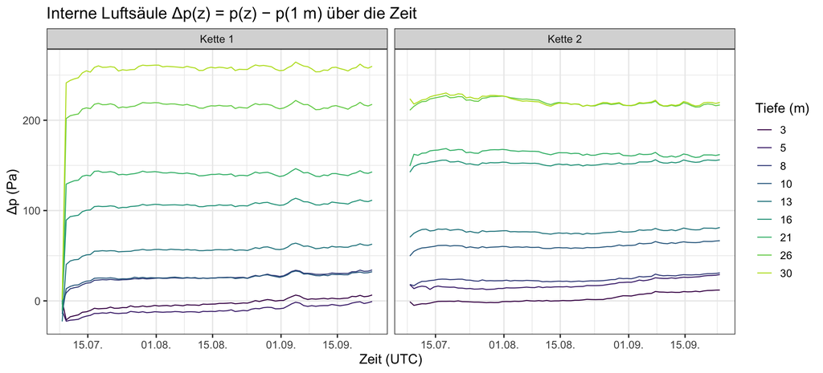

```r
ggplot(p_col |> filter(depth_m > min(depth_m)),
       aes(time, dp_Pa, colour = factor(depth_m))) +
  geom_line(linewidth = 0.45) +
  scale_colour_viridis_d(name = "Tiefe (m)", option = "D", end = 0.9) +
  scale_x_datetime(date_labels = "%d.%m.") +
  facet_wrap(~ chain) +
  labs(title = "Interne Luftsäule Δp(z) = p(z) − p(1 m) über die Zeit",
       x = "Zeit (UTC)", y = "Δp (Pa)") +
  theme_bw(base_size = 13)
```

Dasselbe als **Abweichung jedes Knotens von seinem eigenen Mittel** im ruhigen Fenster — das ist der Teil, in dem ein lokaler Pumpvorgang sichtbar würde.

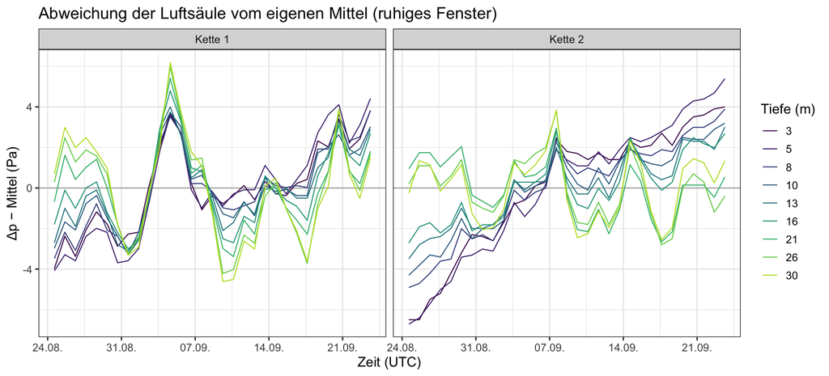

```r
p_col_q |> group_by(chain, depth_m) |> mutate(dev = dp_Pa - mean(dp_Pa)) |> ungroup() |>
  ggplot(aes(time, dev, colour = factor(depth_m))) +
  geom_hline(yintercept = 0, colour = "grey70") +
  geom_line(linewidth = 0.45) +
  scale_colour_viridis_d(name = "Tiefe (m)", option = "D", end = 0.9) +
  scale_x_datetime(date_labels = "%d.%m.") +
  facet_wrap(~ chain) +
  labs(title = "Abweichung der Luftsäule vom eigenen Mittel (ruhiges Fenster)",
       x = "Zeit (UTC)", y = "Δp − Mittel (Pa)") +
  theme_bw(base_size = 13)
```

Das entspricht der Literatur: Firn ist mit Permeabilitäten bis ~3·10⁻⁸ m² so durchlässig ([Albert et al., Siple Dome](https://www.cambridge.org/core/journals/annals-of-glaciology/article/snow-and-firn-permeability-at-siple-dome-antarctica/5FAF88CCA571A1F9C35EC3CA8164AE2F)), dass sich synoptische Druckänderungen praktisch unverzögert bis in mehrere Zehnermeter fortpflanzen — barometrisches Pumpen wirkt deshalb über die ganze Firnsäule ([Buizert & Severinghaus](https://tc.copernicus.org/articles/12/2021/2018/)). Windpumpen ist dagegen ein **hochfrequenter** Vorgang: gemessen wird eine Dämpfung der Druckstörung im Schnee, die unterhalb 0,6 m nur noch Frequenzen über ~0,2 Hz betrifft ([Drake et al.](https://www.frontiersin.org/journals/earth-science/articles/10.3389/feart.2019.00201/full)). Ein Tagesprofil kann davon nichts sehen; die hier gemessene Reststreuung ist die Obergrenze.

## Druck und Temperatur

Die Temperatur im Firn folgt dem Luftdruck: im verfüllten Loch messbar mit rund 0,03 mK/hPa, im offenen von der Advektion in der Bohrlochluft überdeckt. Messung, Theorie (`b = φ/(ρ c)`) und die Herkunft der Unruhe im offenen Loch stehen in einem eigenen Dokument: **`druck_temperatur.qmd`**.

## Save result

```r
slug    <- tools::file_path_sans_ext(basename(primary_file))
outfile <- sprintf("data/chain_%s_%s.csv", slug, format(time_utc, "%Y%m%d_%H%M%S"))
write.csv(nodes, outfile, row.names = FALSE)
cat("Saved:", outfile, "\n")
```

```
Saved: data/chain_301434062008130-rb2609231513_20260923_151317.csv
```

```r
if (multi) {
  ts_file <- sprintf("data/chain_series_imei%s_%s.csv", imei, format(time_utc, "%Y%m%d_%H%M%S"))
  write.csv(series, ts_file, row.names = FALSE)
  cat("Saved series:", ts_file, "\n")
}
```

```
Saved series: data/chain_series_imei301434062008130_20260923_151317.csv
```